# Assignment 2

Author

Rachel Stagner

Published

Sep 27, 2026

## Task 1

**To complete this task, first I loaded the tidyverse library.**

```r
library(tidyverse) #load tidyverse library
```

**Then, I used the readr package to load the college.data.csv file into an object called college_data with the `read_csv()` command**

```r
college_data <- read_csv("./data/collegedata.csv") #load collegedata.csv
```

## Task 2

**Even though the `read_csv()` command gives you a message with the number of rows and columns, you can also use the dplyr command `glimpse()` to see these details:**

```r
glimpse(college_data) #view the rows and column information for the dataframe
```

```
Rows: 7,175
Columns: 12
$ UNITID         <dbl> 100654, 100663, 100690, 100706, 100724, 100751, 100760,…
$ OPEID          <dbl> 100200, 105200, 2503400, 105500, 100500, 105100, 100700…
$ MN_EARN_WNE_P6 <chr> "27800", "37600", "39400", "41300", "23500", "38500", "…
$ INSTNM         <chr> "Alabama A & M University", "University of Alabama at B…
$ SAT_AVG        <dbl> 849, 1125, NA, 1257, 825, 1202, NA, NA, 1009, 1217, 115…
$ ADM_RATE       <dbl> 0.8738, 0.5814, NA, 0.7628, 0.4590, 0.5259, NA, NA, 0.7…
$ UGDS           <dbl> 4616, 12047, 293, 6346, 4704, 31663, 1492, 2888, 4171, …
$ COSTT4_A       <dbl> 22667, 22684, 13380, 22059, 19242, 28422, 13868, NA, 19…
$ AVGFACSAL      <dbl> 7028, 10517, 3857, 9463, 7952, 9802, 5960, 8367, 7251, …
$ GRAD_DEBT_MDN  <chr> "32750", "21833", "22890", "22647", "31500", "23290", "…
$ AGE_ENTRY      <chr> "20.28374137", "23.60797466", "33.6722973", "22.7279196…
$ ICLEVEL        <dbl> 1, 1, 1, 1, 1, 1, 2, 1, 1, 1, 1, 2, 1, 1, 2, 2, 1, 2, 3…
```

**Using either method, we find out that there are 7175 rows and 12 columms in this dataframe.**

## Task 3

**To create a new dataframe with only certain columns, we can use the dplyr command `select()` to choose the requested columns: INSTNM, SAT_AVG, and ADM_RATE.**

```r
#create a new dataframe that has the requested columns
admission_rates <- college_data |> select(INSTNM, SAT_AVG, ADM_RATE)
```

**I like to confirm that everything worked as I wanted by running the `head()` or `glimpse()` command to verify.**

```r
#confirming the new dataframe:
glimpse(admission_rates)
```

```
Rows: 7,175
Columns: 3
$ INSTNM   <chr> "Alabama A & M University", "University of Alabama at Birming…
$ SAT_AVG  <dbl> 849, 1125, NA, 1257, 825, 1202, NA, NA, 1009, 1217, 1150, NA,…
$ ADM_RATE <dbl> 0.8738, 0.5814, NA, 0.7628, 0.4590, 0.5259, NA, NA, 0.7659, 0…
```

## Task 4

**First, I created a new dataframe with the NA rows removed, using the `drop_na()` command from the tidyr package, and `glimpse()` to confirm my changes.**

```r
cleaned_data <- admission_rates |> drop_na() #drop rows with NA values
glimpse(cleaned_data) #confirm dropped values
```

```
Rows: 1,301
Columns: 3
$ INSTNM   <chr> "Alabama A & M University", "University of Alabama at Birming…
$ SAT_AVG  <dbl> 849, 1125, 1257, 825, 1202, 1009, 1217, 1150, 972, 1001, 1062…
$ ADM_RATE <dbl> 0.8738, 0.5814, 0.7628, 0.4590, 0.5259, 0.7659, 0.8054, 0.483…
```

**Then, I used `ggplot()` from the ggplot2 library to create a scatter plot of Average SAT scores versus Admission Rates. I styled it a bit with blue points and the black and white theme, and added axes labels and a title and subtitle.**

**Interestingly, it took me a minute to figure out what this data was telling me, but when I thought about it, it makes sense. The higher the school’s average SAT score, the lower their admission rate due to their high selectivity.**

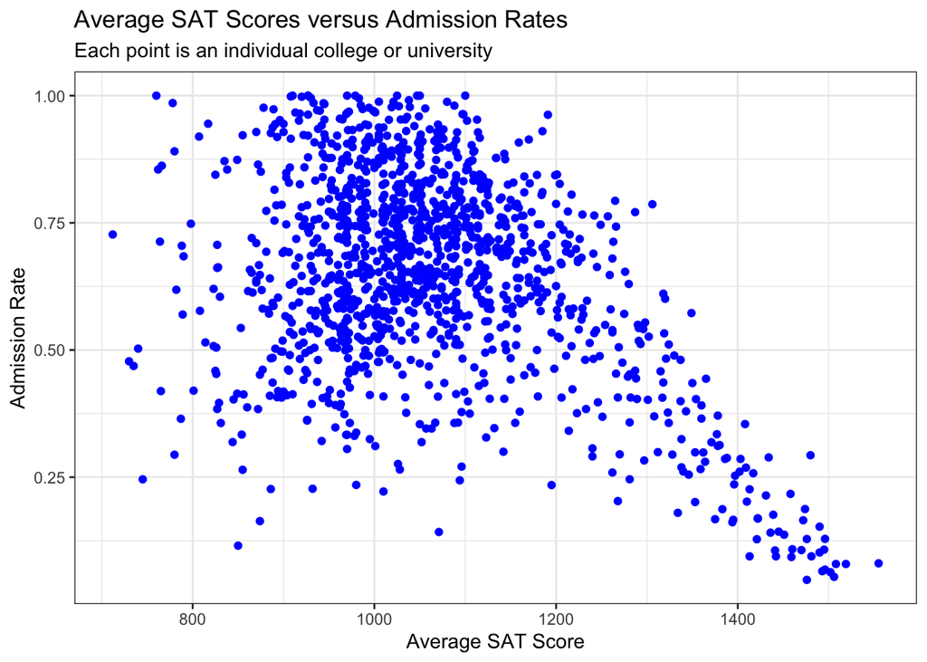

```r
#create a new plot of SAT scores versus admission rate
plot_1 <-  ggplot(cleaned_data, aes(x = SAT_AVG, y = ADM_RATE)) + #create the plot
  geom_point(color="blue") +
  labs(x = "Average SAT Score", #apply labels
       y = "Admission Rate",
       title = "Average SAT Scores versus Admission Rates",
       subtitle = "Each point is an individual college or university") +
  theme_bw() #apply theme

plot_1
```